# Reproducible Research: Peer Assessment 1

## Loading and preprocessing the data

1. Load the data (i.e. read.csv())

```r
data <- read.csv(unz("activity.zip", "activity.csv"), header = T)
```

2. Process/transform the data (if necessary) into a format suitable for your analysis  
   NA.

## What is mean total number of steps taken per day?

1. Ignore the missing values in the dataset.

```r
newdata <- na.omit(data)
```

2. Calculate the total number of steps taken per day

```r
dailysteps <- aggregate(steps ~ date, newdata, sum)
```

2. Make a histogram of the total number of steps taken each day

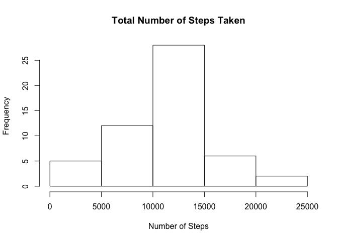

```r
hist(dailysteps$steps,
     main = "Total Number of Steps Taken",
     xlab="Number of Steps")
```

```r
meansteps <- mean(dailysteps$steps)
mediansteps <- median(dailysteps$steps)
```

## What is the average daily activity pattern?

1. Calculate average steps for each interval for all days.

```r
intervalsteps <- aggregate(steps ~ interval, newdata, mean)
```

1. Make a time series plot (i.e. type = “l”) of the 5-minute interval (x-axis) and the average number of steps taken, averaged across all days (y-axis)

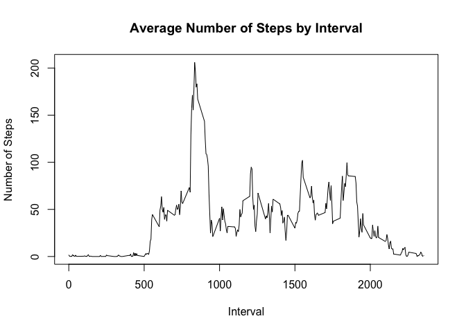

```r
plot(intervalsteps$interval,
     intervalsteps$steps,
     type="l",
     xlab="Interval",
     ylab="Number of Steps",
     main="Average Number of Steps by Interval")
```

2. Which 5-minute interval, on average across all the days in the dataset, contains the maximum number of steps?

```r
maxsteps <- intervalsteps[which.max(intervalsteps$steps), 1]
```

The 5-minute interval, on average across all the days in the dataset, which contains the maximum number of steps is 835.

## Imputing missing values

1. Calculate and report the total number of missing values in the dataset (i.e. the total number of rows with NAs)

```r
missing <- sum(!complete.cases(data))
```

There are 2304 missing values in the dataset.

2. Devise a strategy for filling in all of the missing values in the dataset.  
   The mean for the 5-minute interval will be used to replace the missing values.
3. Create a new dataset that is equal to the original dataset but with the missing data filled in.

```r
cleandata <- transform(data, steps = ifelse(is.na(data$steps), intervalsteps$steps[match(data$interval, intervalsteps$interval)], data$steps))
```

4. Make a histogram of the total number of steps taken each day

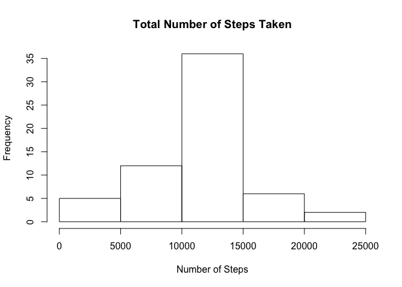

```r
newdailysteps <- aggregate(steps ~ date, cleandata, sum)
hist(newdailysteps$steps,
     main = "Total Number of Steps Taken",
     xlab="Number of Steps")
```

```r
newmeansteps <- mean(dailysteps$steps)
newmediansteps <- median(dailysteps$steps)
```

## Are there differences in activity patterns between weekdays and weekends?

1. Create a new factor variable in the dataset with two levels – “weekday” and “weekend” indicating whether a given date is a weekday or weekend day.

```r
weekdays <- c("Monday", "Tuesday", "Wednesday", "Thursday",
              "Friday")
cleandata$day = as.factor(ifelse(is.element(weekdays(as.Date(cleandata$date)), weekdays), "Weekday", "Weekend"))
```

2. Make a panel plot containing a time series plot (i.e. type = “l”) of the 5-minute interval (x-axis) and the average number of steps taken, averaged across all weekday days or weekend days (y-axis).

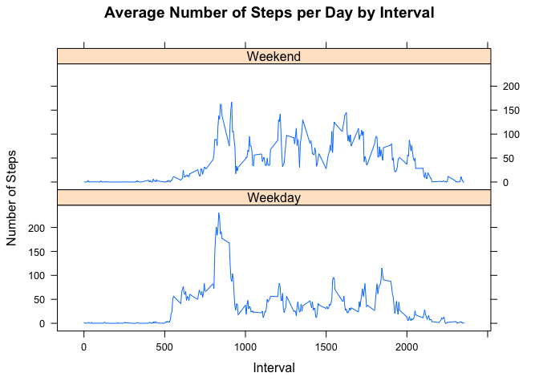

```r
newintervalsteps <- aggregate(steps ~ interval + day, cleandata, mean)
library(lattice)
xyplot(newintervalsteps$steps ~ newintervalsteps$interval|newintervalsteps$day,
       xlab="Interval",
       ylab="Number of Steps",
       main="Average Number of Steps per Day by Interval",
       layout=c(1,2),
       type="l")
```